# MA3622: Practical Machine Learning

#### *variationalform* https://variationalform.github.io/courses_PML/

#### *Just Enough: progress at pace*

https://github.com/variationalform

*Simon Shaw* - https://www.brunel.ac.uk/people/simon-shaw.

## What this module is about:

You will be introduced to ...

- fundamental ideas in machine learning, data science, and artificial intelligence:
  - $k$-NN: $k$-Nearest Neighbours;
  - perceptrons, neural networks and deep learning.
- underpinning mathematical concepts
- `python` implementations

## Assessment

- 25% coursework (details to follow in a few weeks)
- 75% examination (revision and reflection time will be allocated)

## Study Habits - a discussion

The Quality Assurance Agency for Higher Education (QAA, https://www.qaa.ac.uk) defines one academic credit as nominally equal to 10 hours of study (see https://www.qaa.ac.uk/docs/qaa/quality-code/higher-education-credit-framework-for-england.pdf).

Therefore, this 15 credit block requires nominally 150 hours of your time. **Although every one of us is different and may choose to spend our time in different ways**, the following sketch of these 150 hours is worth considering.

There will be $40$ hours spent on two lectures plus two seminars/labs in each of ten weeks (weeks 1-5, 7-11 with reading week in week 6). There will be a two hour exam, to which you could assign $28$ hours of preparation/revision time. This accounts for $40+2+28 = 70$ hours.

In addition there is assignment which you could allocate $20$ hours to, making up to $90$ hours. This leaves $60$ of the $150$ hours over. In each of $10$ weeks of term there will be a requirement to engage in set tasks and problems, and to read sections of set books and sources in order to strengthen your understanding of imparted material as well as to prepare you for the next topics. These $60$ hours average out to $6$ hours per week over those $10$ weeks.

Note that engaging at this level does not guarantee any outcome, whether that be a bare pass or an A grade. It is a guideline only. If despite engaging at this level you are struggling to progress and achieve in the module then seek help and advice.

Further, these *weekly study hours* have to be **high quality inquisitive engagement**. Writing and re-writing notes, procrastinating, passively reading AI outputs and looking at but not engaging with learning materials don't really count.

You'll know when you're actually **working** - you'll feel it. Have a read of this https://en.wikipedia.org/wiki/Flow_(psychology) and make learning a daily rewarding habit.

# Practical Machine Learning

## Introduction to key concepts

- fundamental ideas in machine learning, data science, and artificial intelligence:
- Leading to... $k$-NN: $k$-Nearest Neighbours and Logistic Regression
- underpinning mathematical concepts and `python` implementation with `sklearn`

#### *variationalform:* https://variationalform.github.io/courses_PML/

#### *Just Enough: progress at pace*

https://github.com/variationalform

|  | This work is licensed under CC BY-SA 4.0 (Attribution-ShareAlike 4.0 International) Visit http://creativecommons.org/licenses/by-sa/4.0/ to see the terms. |
| --- | --- |

| This document uses python |  | and also makes use of LaTeX |  | in Markdown |  |
| --- | --- | --- | --- | --- | --- |

> Google and possibly other search engines, both with and without AI enhancement, may have been used in the production of these notes.

> AI tools such as Gemini, Claude, ChaptGPT etc may also have played a role in generating ideas and raw material for the following content.

> Specific inclusions and sources are always referenced.

> However, all planning and quality control is purely human, and my responsibility.

## Key Concepts: Glossary of Relevant Terms

The first few of these are debateable, evolving and subject to change and interpretation. It's worth searching and reading for yourself. These are a fast growing areas.

#### Data Science

A blend of mathematics, computer science and statistics brought to bear with some form of domain expertise.

#### Data Analytics

Systematic computational analysis of data, used typically to discover value and insights.

#### Data Engineering

The stewardship, cleaning, warehousing and preparation of data to support its pipelining to its exploitation.

#### Artificial Intelligence (AI)

The development and deployment of digital systems that can effectively substitute for humans in tasks beyond the routine application of fixed rules. When you talk to your home assistant, your phone, or your satellite TV receiver, or your car, or your laptop, and so on, it has no idea what you are going to say. It doesn't have a bank of pre-answered questions, but instead it responds dynamically to what it hears. It has been trained on data, and it has learned how to respond. Incidentally, how do you think these systems even understand what you said? As a child, it took you months to begin to understand human speech...

#### Machine Learning (ML)

The development and deployment of algorithms that are able to learn from data without explicit instructions, and then analyze, predict, or otherwise draw inferences, from unseen data. These algorithms would typically be expected to add measurable value by their performance.

> *Consider for example an algorithm that predicted **tails** for every coin flip. It's right half the time* - but there's no value in that.

ML is a big part of AI but not all of it. AI has historically drawn on many techniques, but in current times AI is becoming more and more based on ML techniques.

We'll often refer to ML/AI in these notes.

#### Learning

Machine learning models do not have intrinsic knowledge but instead learn from data. Typically a data set comprises a list of items each of which has one or more *features* which correspond to a *label*. We'll see some examples of this below.

We think of the features as being inputs to the machine learning model, and the label as being the output. Typically we want to be able to feed in new features, and have the model predict the label.

To do this we need a **training data set** so that the model can learn how to map the features to the label: the *input to the output*.

There are three basic learning paradigms:

- **Supervised Learning**: Here the data is labelled. This means that for a given set of features, or inputs, we also know their labels, or outputs. Examples of this are where...
  - We could have a list of features of insured drivers, such as age, time since they passed their driving test, type of car, locality, and along with those features a monetary value on their accident claim. The task would be to learn how much of an insurance premium to charge to a new customer once those features have been determined.
  - We might have a bank of images of handwritten digits, and for each image we know what digit is represented. The MNIST database of handwritten digits, see http://yann.lecun.com/exdb/mnist/ or https://en.wikipedia.org/wiki/MNIST_database for example, is a well known example of this. The task is to learn how to predict what digit is captured by a new image. This could be used in ANPR systems for example, https://en.wikipedia.org/wiki/Automatic_number-plate_recognition.
- **Unsupervised Learning**: This is where we only know the features and we want to cluster the data in such a way that a set of similar features can be assiociated with some common characteristic (the label).
  - This can be used on data where the analyst doesn't initially know what they are looking for. For example, a retailer might have a mass of data of customer age, locale, average spend, types of purchased item, time of day of purchase, day of week of purchase, time of year etc. What characteristics can be used to group these customers? How can advertising be targetted?
  - principal component analysis seeks to re-orient data so that its dominant statistical properties are revealed (this is covered in a different module).
- **Reinforcement Learning**: This seeks to strike a balance between the two above. There are no labels, but instead, as time progresses the learning algorithm has a *reward* variable which is increased when an action it has learned has resulted in a measurable benefit. Over time the algorithm develops a policy to inform its actions.

Our module is concerned mainly with **supervised learning**.

#### Regression and Classification

**Machine Learning algorithms** usually perform one of the following tasks:

- **Regression:** here the output, the label, can take any value in a continuous set. For example, the height of a tree, given local climate, soil type, genus, age since planting, could be considered to be any non-negative real number (although not with equal probability).
- **Classification:** in this case the label will be deemed to be one of a certain class. For example, in the handwritten digits example above, the output will be one of the digits $\{0,1,2,3,\ldots,9\}$.

Some algorithms are able to perform both the regression and classification tasks, some are specialized to just one task.

## Reading List

Our main sources of information are as follows:

- MML: Mathematics for Machine Learning, by Marc Peter Deisenroth, A. Aldo Faisal, and Cheng Soon Ong. Cambridge University Press. https://mml-book.github.io.
- MLF: Machine Learning: A First Course for Engineers and Scientists, by Andreas Lindholm, Niklas Wahlström, Fredrik Lindsten, Thomas B. Schön. Cambridge University Press. http://smlbook.org.
- MLF2 - as abpve but the second edition also linked at http://smlbook.org
- UDL: Understanding Deep Learning, by S.J.D.Prince. MIT Press, 2023. https://udlbook.github.io/udlbook

All of the above can be accessed legally and without cost.

There are also these useful references for coding:

- PT: `python`: https://docs.python.org/3/tutorial
- NP: `numpy`: https://numpy.org/doc/stable/user/quickstart.html
- MPL: `matplotlib`: https://matplotlib.org

The capitalized abbreviations will be used throughout to refer to these sources. For example, we could say *See [MLF, Chap 2, Sec. 1] for more discussion of **Supervised Learning***. This would just be a quick way of saying

> Look in Section 1, of Chapter 2, of the first edition of Machine Learning: A First Course for Engineers and Scientists, by Andreas Lindholm, Niklas Wahlström, Fredrik Lindsten, Thomas B. Schön, for more discussion of supervised learning.

There may be other sources shared as we go along. For now these will get us a long way.

## Coding: `python` and some data sets

We use `python` because its use in commercial and academic ML/AI seems to be pre-eminent.

much of our code is implemented in well-known and well-documented `python` libraries. These are the main ones we will use:

- `matplotlib`: used to create visualizations, plotting 2D graphs in particular.
- `numpy`: this is *numerical python*, it is used for array processing which for us will usually mean the numerical calculations involving vectors and matrices.
- `scikit-learn`: a set of well documented and easy to use tools for predictive data analysis.
- `pandas`: a data analysis tool, used for the storing and manipulation of data.
- `seaborn`: a data visualization library for attractive and informative statistical graphics.

There will be others, but these are the main ones.

## Binder, Anaconda, Jupyter - a first look at some data

Eventually we will use the anaconda distribution to access `python` and the libraries we need. The coding itself will be carried out in a Jupyter notebook. We'll go through this in an early lab session. We'll start though with Binder: click here:

https://mybinder.org/v2/gh/variationalform/PML.git/HEAD

Let's see some code and some data. In the following cell we import `seaborn` and look at the names of the built in data sets. The `seaborn` library, https://seaborn.pydata.org, is designed for data visualization. It uses `matplotlib`, https://matplotlib.org, which is a graphics library for `python`.

If you want to dig deeper, you can look at https://blog.enterprisedna.co/how-to-load-sample-datasets-in-python/ and https://github.com/mwaskom/seaborn-data for the background - but you don't need to.

```python
import seaborn as sns
# we can now refer to the seaborn library functions using 'sns'
# you could use another character string, but 'sns' is standard.

# note that # is used to write 'comments'
# Now let's get the names of the built-in data sets.
datasets = sns.get_dataset_names()
for dataset in datasets:
    print(dataset, end=', ')
# type SHIFT=RETURN to execute the highlighted (active) cell
```

```
anagrams, anscombe, attention, brain_networks, car_crashes, diamonds, dots, dowjones, exercise, flights, fmri, geyser, glue, healthexp, iris, mpg, penguins, planets, seaice, taxis, tips, titanic,
```

### The `taxis` data set

Below, the variable `dft` is a pandas data frame: `dft` = 'data frame taxis'

```python
# let's take a look at 'taxis'
dft = sns.load_dataset('taxis')
# this just plots the first few lines of the data
dft.head()
```

|  | pickup | dropoff | passengers | distance | fare | tip | tolls | total | color | payment | pickup_zone | dropoff_zone | pickup_borough | dropoff_borough |
| --- | --- | --- | --- | --- | --- | --- | --- | --- | --- | --- | --- | --- | --- | --- |
| 0 | 2019-03-23 20:21:09 | 2019-03-23 20:27:24 | 1 | 1.60 | 7.0 | 2.15 | 0.0 | 12.95 | yellow | credit card | Lenox Hill West | UN/Turtle Bay South | Manhattan | Manhattan |
| 1 | 2019-03-04 16:11:55 | 2019-03-04 16:19:00 | 1 | 0.79 | 5.0 | 0.00 | 0.0 | 9.30 | yellow | cash | Upper West Side South | Upper West Side South | Manhattan | Manhattan |
| 2 | 2019-03-27 17:53:01 | 2019-03-27 18:00:25 | 1 | 1.37 | 7.5 | 2.36 | 0.0 | 14.16 | yellow | credit card | Alphabet City | West Village | Manhattan | Manhattan |
| 3 | 2019-03-10 01:23:59 | 2019-03-10 01:49:51 | 1 | 7.70 | 27.0 | 6.15 | 0.0 | 36.95 | yellow | credit card | Hudson Sq | Yorkville West | Manhattan | Manhattan |
| 4 | 2019-03-30 13:27:42 | 2019-03-30 13:37:14 | 3 | 2.16 | 9.0 | 1.10 | 0.0 | 13.40 | yellow | credit card | Midtown East | Yorkville West | Manhattan | Manhattan |

```python
# this will show the last two lines... There are 6433 records (Why?)
dft.tail(2)
```

|  | pickup | dropoff | passengers | distance | fare | tip | tolls | total | color | payment | pickup_zone | dropoff_zone | pickup_borough | dropoff_borough |
| --- | --- | --- | --- | --- | --- | --- | --- | --- | --- | --- | --- | --- | --- | --- |
| 6431 | 2019-03-04 10:09:25 | 2019-03-04 10:14:29 | 1 | 1.12 | 6.0 | 0.00 | 0.0 | 6.80 | green | credit card | East New York | East Flatbush/Remsen Village | Brooklyn | Brooklyn |
| 6432 | 2019-03-13 19:31:22 | 2019-03-13 19:48:02 | 1 | 3.85 | 15.0 | 3.36 | 0.0 | 20.16 | green | credit card | Boerum Hill | Windsor Terrace | Brooklyn | Brooklyn |

What we are seeing here is a **data frame**. It is furnished by the `pandas` library: https://pandas.pydata.org which is used by the `seaborn` library to store its example data sets. Each row of the data frame corresponds to a single **data point**, which we could also call an `observation` or `measurement` (depending on context).

Each column (except the left-most) corresponds to a **feature** of the data point. The first column is just an index giving the row number. Note that this index starts at zero - so, for example, the third row will be labelled/indexed as $2$. Be careful of this - it can be confusing.

```python
# let's print the data frame...
print(dft)
```

```
                  pickup             dropoff  passengers  distance  fare  \
0    2019-03-23 20:21:09 2019-03-23 20:27:24           1      1.60   7.0
1    2019-03-04 16:11:55 2019-03-04 16:19:00           1      0.79   5.0
2    2019-03-27 17:53:01 2019-03-27 18:00:25           1      1.37   7.5
3    2019-03-10 01:23:59 2019-03-10 01:49:51           1      7.70  27.0
4    2019-03-30 13:27:42 2019-03-30 13:37:14           3      2.16   9.0
...                  ...                 ...         ...       ...   ...
6428 2019-03-31 09:51:53 2019-03-31 09:55:27           1      0.75   4.5
6429 2019-03-31 17:38:00 2019-03-31 18:34:23           1     18.74  58.0
6430 2019-03-23 22:55:18 2019-03-23 23:14:25           1      4.14  16.0
6431 2019-03-04 10:09:25 2019-03-04 10:14:29           1      1.12   6.0
6432 2019-03-13 19:31:22 2019-03-13 19:48:02           1      3.85  15.0

       tip  tolls  total   color      payment            pickup_zone  \
0     2.15    0.0  12.95  yellow  credit card        Lenox Hill West
```

[output cut: 25 more lines]

#### Visualization

What a mess! Rows and rows of numbers aren't that helpful. `seaborn` makes visualization easy - here is a scatter plot of the data.

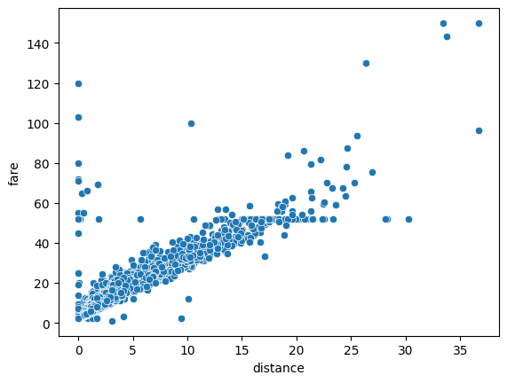

```python
sns.scatterplot(data=dft, x="distance", y="fare");
```

> **THINK ABOUT**: it looks like fare is roughly proportional to distance. But what could cause the outliers?

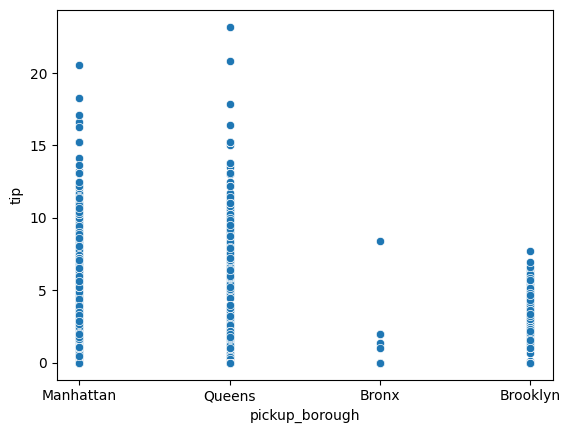

```python
# here's another example
sns.scatterplot(data=dft, x="pickup_borough", y="tip");
```

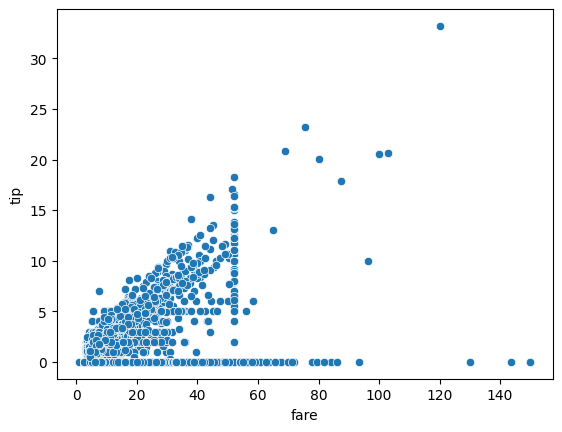

```python
# is the tip proportional to the fare?
sns.scatterplot(data=dft, x="fare", y="tip");
```

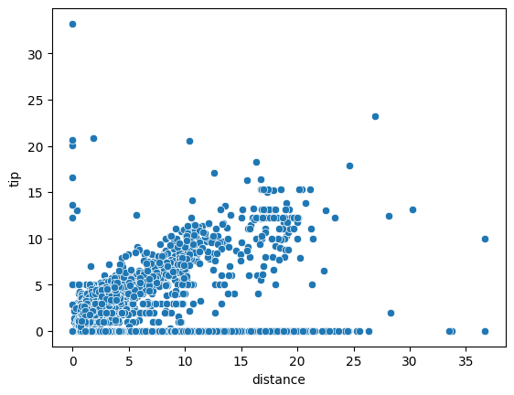

```python
# is the tip proportional to the distance?
sns.scatterplot(data=dft, x="distance", y="tip");
```

## Exercises

For the `taxis` data set:

```
1: sns.scatterplot(data=ds, x="dropoff_borough", y="tip")
2: sns.scatterplot(data=ds, x="distance", y="tip")
```

# Next Steps...

Let's look now at a fundamental ML algorithm...

**$k$-NN: $k$ Nearest Neighbours**

We'll move to the next set of slides.